# Puromycin Practice

Haley Reed

5/27/2020

**Introduction**

It is relevant to explore the effects and reaction times of Puromycin for its’ application in biology. This report will use the data collected by Margret Treloar in 1974 in extermination with rat livers to explore these reaction times. Using this data obtained from R, this report will explore how substrate concentration (measured in parts per million) and the presence (or lack thereof) of the antibiotic Puromycin can act as explanatory variables and model the reaction rate of enzymes. The rate, our dependent variable, is measured by the number of counts per minute of radioactive product.

**Analysis**

To begin our exploration of the data, we start with a scatterplot of the rate represented by the explanatory variable concentration and differentiate treated with black pointed and untreated with red.

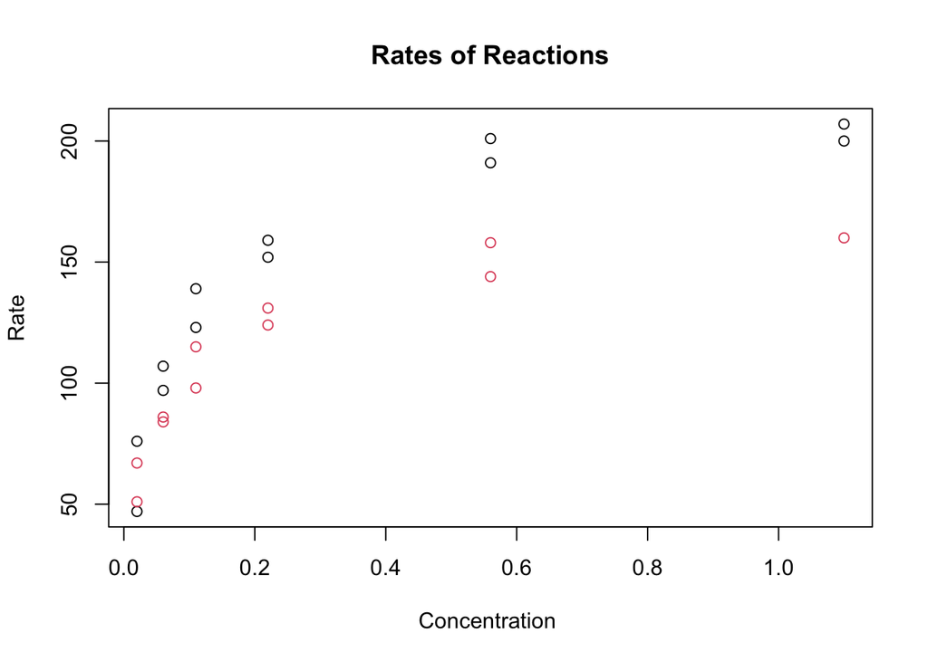

The data appears to be skewed to the right. The untreated data points appear to have reactions that may have statistically significantly slower reaction rates. The patterns present in this scatterplot demonstrate that it would be helpful to build a model based on both concentration and state (treated or untreated) to model reaction rates. There appears to be a moderately strong positive relationship between the two variables of concentration, however the relationship appears to not be particularly linear. To address concerns of linearity, we will apply a logarithmic transformation to the numeric explanatory variable of concentration.

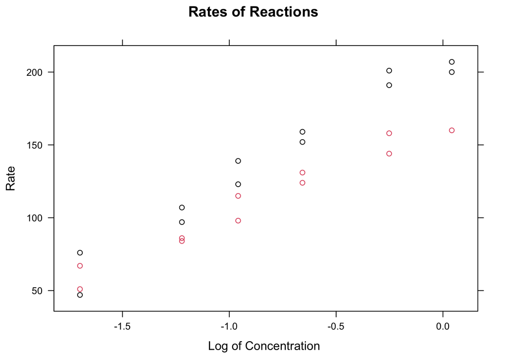

A logarithmic transformation of concentration results in a graph that looks more appropriate for a linear model.

From here, there are two major models worth discussing:

1. A Simple Linear Regression Model
2. An ANCOVA model

Even though the ANOVA model is slightly more complicated because of the added categorical value of state (treated versus untreated) we ultimately prefer it for the following reasons:

It has an adjusted multiple R-squared value of 0.9629 versus the Simple Linear Regression model’s 0.9435. The ANCOVA model is able to explain 96.2902% of the variance in rate, making it a good option for model selection.

The ANCOVA model has an AIC value of 172.7171, a value 9.6658 units lower that the Simple Linear Regression model, meeting the statistical heuristic of significance for AIC because 9.6658>2.

The F-Test produces a P-Value of 2.41 × 10^(-6), a value well below the statistically significant 5%. This means we can reject the null hypothesis that the simpler model is better.

Therefore, we will go forward with the fitted model for ANCOVA given by:
$$\mu [rate ~ conc, state ] = 209.1945 + 85.4499(logconc) +-23.3214(logconc) \times I(state=untreated) + -44.6061 \times I(state=untreated)$$

Since the primary difference between our two models is the differentiation between treated and untreated data, it is worth exploring the following confidence intervals:

|  | 2.5 % | 97.5 % |
| --- | --- | --- |
| (Intercept) | 199.87 | 218.516 |
| logconc | 75.97 | 94.934 |
| stateuntreated | -58.86 | -30.351 |
| logconc:stateuntreated | -37.48 | -9.167 |

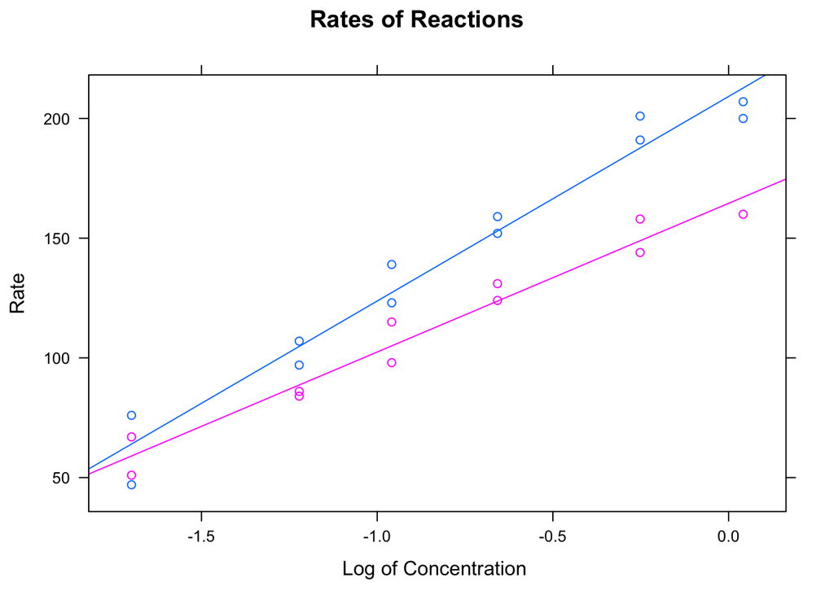

Contextually, this means for a treated enzyme (shown in blue):

- When the concentration is 1, the model predicts a rate of 209.1945 counts per minute.
- When the concentration goes up by a factor of 10, the rate will increase by 85.4499 counts per minute.

**Sampling Variability Assumptions**

We will check the following Sampling Variability Assumptions of our ANCOVA model:

1. The relationship between explanatory and dependent numerical variables is linear.
2. There is homogeneity of regression slopes.

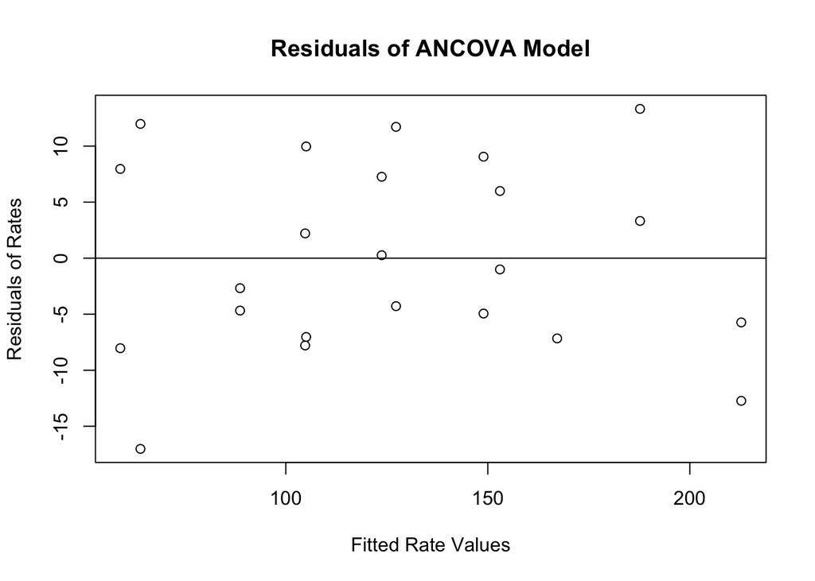

**Conclusion**